# PISA Data exploration

## by Praprara Owodeha-Ashaka

## Introduction

PISA is a survey of students' skills and knowledge as they approach the end of compulsory education. This survey examines how well students have learned the school curriculum, how well prepared they are for life beyond school. Around 510,000 students in 65 economies took part in the PISA 2012 assessment of reading, mathematics and science. Of those economies, 44 took part in an assessment of creative problem solving and 18 in an assessment of financial literacy.

The colum names in the data are non descriptive short forms because the descriptive column names will be too long. The DataFrame "data_dict" contains the description of each column. We shall make reference to it often

## Preliminary Wrangling

```python
# import all packages and set plots to be embedded inline
import numpy as np
import pandas as pd
import matplotlib.pyplot as plt
import seaborn as sns

%matplotlib inline

# suppress warnings from final output
import warnings
warnings.simplefilter("ignore")
```

```python
df = pd.read_csv('pisa2012.csv')
```

```python
data_dict = pd.read_csv('pisadict2012.csv')
```

```python
data_dict.head()
```

|  | Unnamed: 0 | x |
| --- | --- | --- |
| 0 | CNT | Country code 3-character |
| 1 | SUBNATIO | Adjudicated sub-region code 7-digit code (3-di... |
| 2 | STRATUM | Stratum ID 7-character (cnt + region ID + orig... |
| 3 | OECD | OECD country |
| 4 | NC | National Centre 6-digit Code |

```python
for row in range(len(data_dict)):

    print(data_dict.iloc[row])
```

[output not shown]

[output cut: 1850 more lines]

```
Unnamed: 0                                    W_FSTR80
x             FINAL STUDENT REPLICATE BRR-FAY WEIGHT80
Name: 630, dtype: object
Unnamed: 0                                    WVARSTRR
x             RANDOMIZED FINAL VARIANCE STRATUM (1-80)
Name: 631, dtype: object
Unnamed: 0                           VAR_UNIT
x             RANDOMLY ASSIGNED VARIANCE UNIT
Name: 632, dtype: object
Unnamed: 0                                           SENWGT_STU
x             Senate weight - sum of weight within the count...
Name: 633, dtype: object
Unnamed: 0                          VER_STU
x             Date of the database creation
Name: 634, dtype: object
```

```python
df.shape
```

```
(485490, 636)
```

```python
df.describe().columns
```

```
Index(['Unnamed: 0', 'SUBNATIO', 'SCHOOLID', 'STIDSTD', 'ST01Q01', 'ST02Q01',
       'ST03Q01', 'ST03Q02', 'ST06Q01', 'ST115Q01',
       ...
       'W_FSTR74', 'W_FSTR75', 'W_FSTR76', 'W_FSTR77', 'W_FSTR78', 'W_FSTR79',
       'W_FSTR80', 'WVARSTRR', 'VAR_UNIT', 'SENWGT_STU'],
      dtype='object', length=268)
```

```python
#print(list(df.columns))
```

```python
df.iloc[:,:20].info()
```

```
<class 'pandas.core.frame.DataFrame'>
RangeIndex: 485490 entries, 0 to 485489
Data columns (total 20 columns):
 #   Column      Non-Null Count   Dtype
---  ------      --------------   -----
 0   Unnamed: 0  485490 non-null  int64
 1   CNT         485490 non-null  object
 2   SUBNATIO    485490 non-null  int64
 3   STRATUM     485490 non-null  object
 4   OECD        485490 non-null  object
 5   NC          485490 non-null  object
 6   SCHOOLID    485490 non-null  int64
 7   STIDSTD     485490 non-null  int64
 8   ST01Q01     485490 non-null  int64
 9   ST02Q01     485438 non-null  float64
 10  ST03Q01     485490 non-null  int64
 11  ST03Q02     485490 non-null  int64
 12  ST04Q01     485490 non-null  object
 13  ST05Q01     476166 non-null  object
 14  ST06Q01     457994 non-null  float64
 15  ST07Q01     436690 non-null  object
 16  ST07Q02     431278 non-null  object
 17  ST07Q03     305687 non-null  object
 18  ST08Q01     479143 non-null  object
 19  ST09Q01     479131 non-null  object
dtypes: float64(2), int64(7), object(11)
memory usage: 74.1+ MB
```

```python
df.head(3)
```

|  | Unnamed: 0 | CNT | SUBNATIO | STRATUM | OECD | NC | SCHOOLID | STIDSTD | ST01Q01 | ST02Q01 | ... | W_FSTR75 | W_FSTR76 | W_FSTR77 | W_FSTR78 | W_FSTR79 | W_FSTR80 | WVARSTRR | VAR_UNIT | SENWGT_STU | VER_STU |
| --- | --- | --- | --- | --- | --- | --- | --- | --- | --- | --- | --- | --- | --- | --- | --- | --- | --- | --- | --- | --- | --- |
| 0 | 1 | Albania | 80000 | ALB0006 | Non-OECD | Albania | 1 | 1 | 10 | 1.0 | ... | 13.7954 | 13.9235 | 13.1249 | 13.1249 | 4.3389 | 13.0829 | 19 | 1 | 0.2098 | 22NOV13 |
| 1 | 2 | Albania | 80000 | ALB0006 | Non-OECD | Albania | 1 | 2 | 10 | 1.0 | ... | 13.7954 | 13.9235 | 13.1249 | 13.1249 | 4.3389 | 13.0829 | 19 | 1 | 0.2098 | 22NOV13 |
| 2 | 3 | Albania | 80000 | ALB0006 | Non-OECD | Albania | 1 | 3 | 9 | 1.0 | ... | 12.7307 | 12.7307 | 12.7307 | 12.7307 | 4.2436 | 12.7307 | 19 | 1 | 0.1999 | 22NOV13 |

3 rows × 636 columns

```python
df['ST46Q07'].value_counts()
```

```
Agree                177887
Strongly agree        90494
Disagree              35911
Strongly disagree      8562
Name: ST46Q07, dtype: int64
```

```python
df[['ST46Q01','ST46Q02','ST46Q03','ST46Q04','ST46Q05','ST46Q06', 'ST46Q07', 'ST46Q08', 'ST46Q09']]
```

|  | ST46Q01 | ST46Q02 | ST46Q03 | ST46Q04 | ST46Q05 | ST46Q06 | ST46Q07 | ST46Q08 | ST46Q09 |
| --- | --- | --- | --- | --- | --- | --- | --- | --- | --- |
| 0 | Agree | Agree | Agree | Agree | Agree | Agree | Agree | Agree | Agree |
| 1 | Agree | Agree | Strongly agree | Strongly agree | Strongly agree | Agree | Agree | Disagree | Agree |
| 2 | Strongly agree | Strongly agree | Strongly agree | Strongly agree | Strongly agree | Agree | Strongly agree | Strongly agree | Strongly agree |
| 3 | NaN | NaN | NaN | NaN | NaN | NaN | NaN | NaN | NaN |
| 4 | Strongly agree | Strongly agree | Agree | Strongly agree | Strongly agree | Agree | Strongly agree | Strongly agree | Strongly agree |
| ... | ... | ... | ... | ... | ... | ... | ... | ... | ... |
| 485485 | Agree | Agree | Agree | Agree | Disagree | Agree | Agree | Agree | Disagree |
| 485486 | Agree | Agree | Agree | Agree | Agree | Agree | Agree | Agree | Agree |
| 485487 | Agree | Disagree | Agree | Agree | Disagree | Agree | Agree | Disagree | Agree |
| 485488 | NaN | NaN | NaN | NaN | NaN | NaN | NaN | NaN | NaN |
| 485489 | Agree | Agree | Agree | Agree | Disagree | Disagree | Agree | Disagree | Disagree |

485490 rows × 9 columns

### What is the structure of your dataset?

> There are 485,490 rows of data here. Many of the of the columns are categorical. Some are Assessments of how strongly the students agree or disagree to certain things. Others are assessments of how frequently the students encounter certain things. For many of the columns, it is not clear what exactly they represent. I have left those columns out of my anslysis. There are also 636 columns. Visual assessment of the data was impossible because it was too big to open on microsoft excel, which is what I have access to.

### What is/are the main feature(s) of interest in your dataset?

> I'm most interested in the factors that affect/contribute the students learning experience and performance, such as their perseverance and wealth levels and teacher's attitude, and access to resources.

> I will also be looking at the plausible maths, science and reading scores to access student abilities

### What features in the dataset do you think will help support your investigation into your feature(s) of interest?

> There's a whole lot of them. This data is rich, packed to the brim. To name a few, the number of books owned column will help me assess their students reading score. The type of calculator owned will help me assess the students maths scores. More will be revealed during the course of the exploration

This data contains many columns. But these are the ones I will look at

1. Country - 'CNT'
2. AGE - 'AGE'
3. Grade compared to modal grade in country - 'GRADE'
4. Wealth - 'WEALTH'
5. Perseverance - 'PERSEV'
6. Out-of-School Study Time - 'OUTHOURS'
7. Attributions to Failure - Teacher Didnt Get Students Interested - 'ST44Q07'
8. How many books Students have at home - 'ST28Q01'
9. Plausible value 1 in reading- 'PV1READ'
10. Plausible value 1 in science - 'PV1SCIE'
11. Plausible value 1 in mathematics - 'PV1MATH'
12. OTL - Algebraic Word Problem in Math Lesson - 'ST73Q01'
13. OTL - Algebraic Word Problem in Tests - 'ST73Q02'
14. OTL - Applied Math Reasoning in Math Lesson - 'ST76Q01'
15. OTL - Applied Math Reasoning in Tests - 'ST76Q02'
16. Calculator Use - 'CLCUSE1'
17. Can Succeed with Enough Effort - 'ST43Q01'
18. Doing well is completely up to me - 'ST43Q02'
19. A measure of openness to problem solving - 'OPENPS'
20. Parents Believe Mathematics Is Important for Career - 'ST35Q05'
21. Parents Like Maths - 'ST35Q06'
22. Gender - 'ST04Q01'

## Univariate Exploration

Let's look at the country distribution of the students

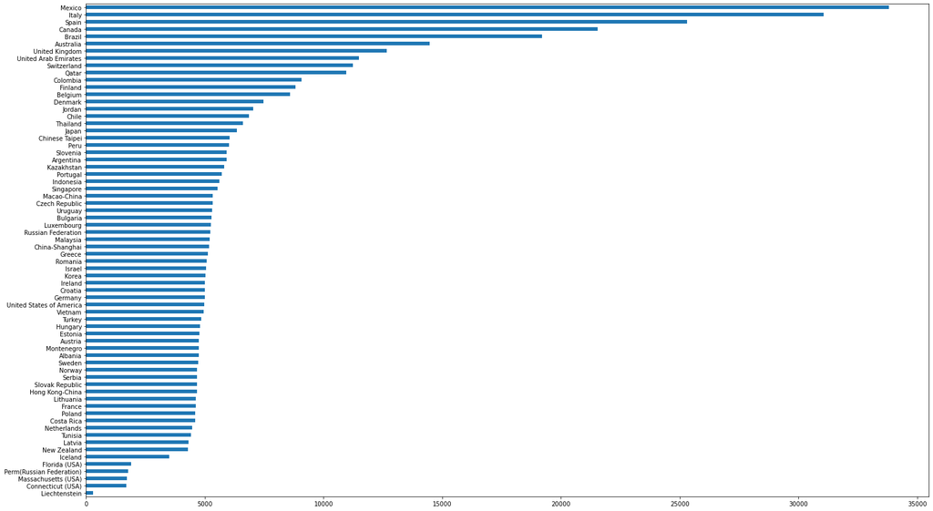

```python
plt.figure(figsize = (25,15))

df['CNT'].value_counts().sort_values(ascending  = True).plot(kind = 'barh')
```

Mexico has the highest number of students represented here Let's now look at their ages

## Students Ages:

#### How is the ages of the students distributed? Are there any precarious learners? Are there any late bloomers?

```python
df['AGE'].describe()
```

```
count    485374.000000
mean         15.784283
std           0.290221
min          15.170000
25%          15.580000
50%          15.750000
75%          16.000000
max          16.330000
Name: AGE, dtype: float64
```

We'll make a function to plot a boxplot and histogram together to look at the distribution

```python
def hist_box_dist(column, bins = None,  title = None, xlabel = None):
    fig, (ax1, ax2) = plt.subplots(nrows=2, ncols=1, figsize=(15, 6))
    ax1.hist(df[column], bins=bins, color='c', alpha=0.5, histtype='bar', edgecolor = 'black')

    ax1.set_ylabel('Count', fontsize = 14)
    ax1.set_title(title, fontsize = 17)
    df[column].plot(kind = 'box', vert = False, ax = ax2)
    ax2.set_xlabel(xlabel, fontsize = 14)
    ax2.set_ylabel(' ', fontsize = 14)

    xticks = ax1.get_xticks()
    ax2.set_xticks(xticks)
```

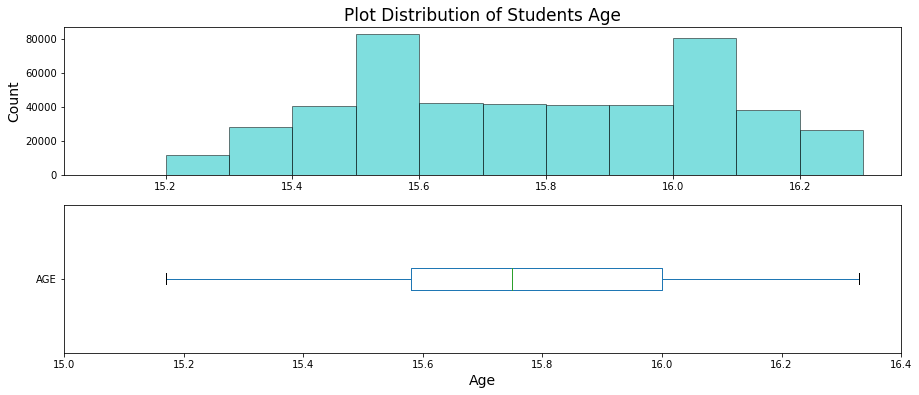

```python
hist_box_dist(column = 'AGE', bins = np.arange(15.1, 16.4, 0.1),
              title = 'Plot Distribution of Students Age', xlabel = 'Age')
```

There are no kids younger than 15 or up to 17. The survey was quite precise as regards age of subjects. The distribution is bimodal with most students being between 15.5 and 15.6 years, and 16.0 and 16.1 years

Now, let's look at how the grades are distributed

## Grades distribution

The GRADE column talks about the student's grade in relation to the modal grade in the country

```python
df['GRADE'].describe()
```

```
count    484617.000000
mean         -0.162964
std           0.655558
min          -3.000000
25%           0.000000
50%           0.000000
75%           0.000000
max           3.000000
Name: GRADE, dtype: float64
```

```python
df['GRADE'].value_counts()
```

```
 0.0    348298
-1.0     76159
 1.0     39179
-2.0     15528
-3.0      4370
 2.0      1078
 3.0         5
Name: GRADE, dtype: int64
```

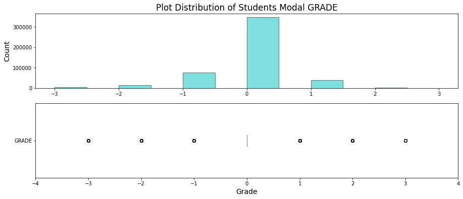

```python
hist_box_dist(column = 'GRADE', bins = 12,
              title = 'Plot Distribution of Students Modal GRADE', xlabel = 'Grade')
```

What this means is that most of the students are proper representations of the average academic performance in their countries

Since this is a categorical variable, let's set the order

```python
Grades_arranged = [-3.0, -2.0, -1.0, 0.0, 1.0, 2.0, 3.0]
grade_levels = pd.api.types.CategoricalDtype(ordered=True, categories=Grades_arranged)

df['GRADE'] = df['GRADE'].astype(grade_levels);
```

```python
grade_levels
```

```
CategoricalDtype(categories=[-3.0, -2.0, -1.0, 0.0, 1.0, 2.0, 3.0], ordered=True)
```

There's a wealth column here. Let's see what that looks like

```python
df['WEALTH'].describe()
```

```
count    479597.00000
mean         -0.33701
std           1.21530
min          -6.65000
25%          -1.04000
50%          -0.30000
75%           0.43000
max           3.25000
Name: WEALTH, dtype: float64
```

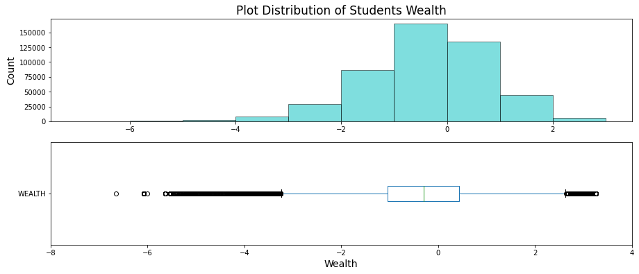

```python
hist_box_dist(column = 'WEALTH', bins  = np.arange(-7, 4, 1),
              title = 'Plot Distribution of Students Wealth', xlabel = 'Wealth')
```

# Perseverance

Let's look at the perseverance column

```python
df['PERSEV'].describe()
```

```
count    313172.000000
mean          0.140125
std           0.996012
min          -4.053000
25%          -0.340700
50%           0.051100
75%           0.479500
max           3.528600
Name: PERSEV, dtype: float64
```

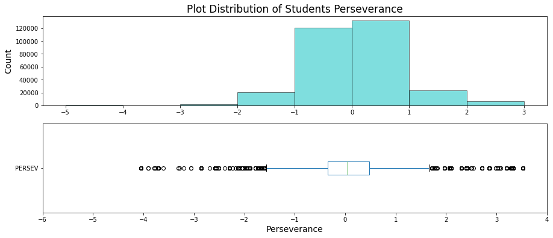

```python
hist_box_dist(column = 'PERSEV', bins  = np.arange(-5, 4, 1), xlabel = 'Perseverance',
              title = f'Plot Distribution of Students Perseverance', )
```

## Out of school Study time

```python
df['OUTHOURS']
```

```
0          NaN
1          8.0
2         24.0
3         17.0
4          NaN
          ...
485485     8.0
485486     NaN
485487     NaN
485488    13.0
485489    21.0
Name: OUTHOURS, Length: 485490, dtype: float64
```

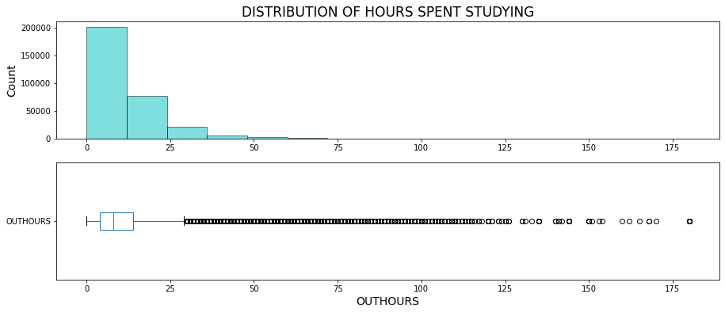

```python
fig, (ax1, ax2) = plt.subplots(nrows=2, ncols=1, figsize=(15, 6))
ax1.hist(df['OUTHOURS'], bins=15, color='c', alpha=0.5, edgecolor = 'black')

ax1.set_ylabel('Count', fontsize = 14)
ax1.set_title('DISTRIBUTION OF HOURS SPENT STUDYING', fontsize = 17)
df['OUTHOURS'].plot(kind = 'box', vert = False, ax = ax2)
ax2.set_xlabel('OUTHOURS', fontsize = 14)
ax2.set_ylabel('', fontsize = 14)
```

### Let's look at the column that details the amount of books the students have at home

```python
df['ST28Q01'].unique()
```

```
array(['0-10 books ', '201-500 books ', 'More than 500 books',
       '11-25 books ', '101-200 books ', '26-100 books ', nan],
      dtype=object)
```

Let's make sure that they are ordered by magnitude

```python
num_books = ['0-10 books ', '11-25 books ', '26-100 books ', '101-200 books ', '201-500 books ', 'More than 500 books',
       ]
#num_books = pd.api.types.CategoricalDtype(ordered=True, categories=num_books)

df['ST28Q01'] = df['ST28Q01'].astype(object);
```

```python
df['ST28Q01'].value_counts().sort_values().reindex(num_books)
```

```
0-10 books              95042
11-25 books             97335
26-100 books           135184
101-200 books           68350
201-500 books           49267
More than 500 books     28587
Name: ST28Q01, dtype: int64
```

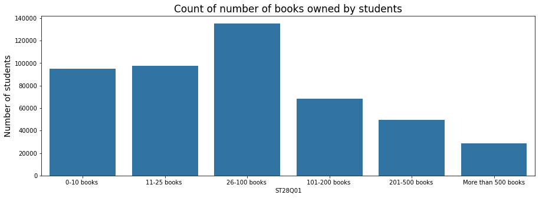

```python
plt.figure(figsize = [15, 5])
sns.countplot(data=df, x='ST28Q01', color=sns.color_palette()[0], order=num_books);
#plt.xlabel('Number of Books', fontsize = 14)
plt.title('Count of number of books owned by students', fontsize = 17)
plt.ylabel('Number of students', fontsize = 14)
```

## Calculator Type

'CLCUSE1' talks about the kind of calculator the students use

```python
df['CLCUSE1'].value_counts()
```

```
A Simple calculator        173659
A Scientific calculator    156372
No calculator               63775
A Graphics calculator       12851
A CAS calculator             5680
Name: CLCUSE1, dtype: int64
```

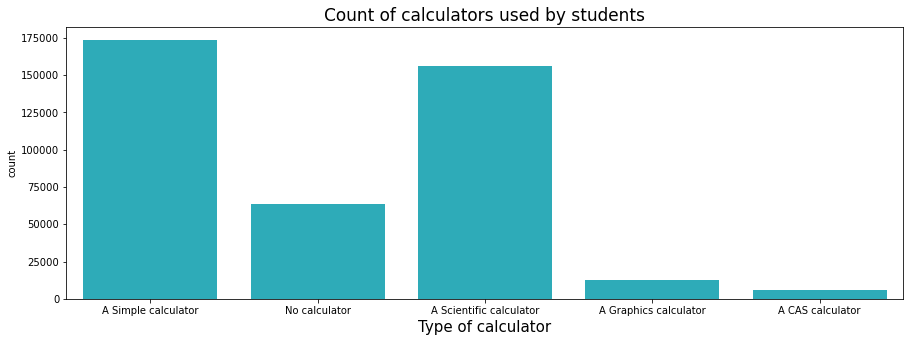

```python
plt.figure(figsize = (15, 5))
sns.countplot(data = df, x = 'CLCUSE1', color=sns.color_palette()[9])
plt.title('Count of calculators used by students', fontsize = 17)
plt.xlabel('Type of calculator', fontsize = 15);
```

Most students use a simple calculator. It's quite interesting that some students use no calculators. How do they survive math tests?

## Problem solving

We shall now look at the distribution of students openness to problem solving

```python
df['OPENPS'].describe()
```

```
count    312766.000000
mean          0.038895
std           0.998720
min          -3.633300
25%          -0.543300
50%           0.052100
75%           0.463900
max           2.446500
Name: OPENPS, dtype: float64
```

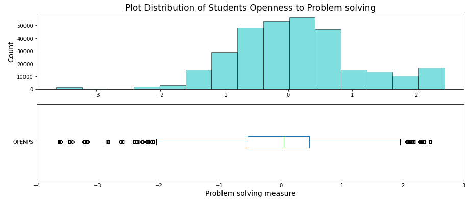

```python
hist_box_dist(column = 'OPENPS', bins = 15,
              title = 'Plot Distribution of Students Openness to Problem solving', xlabel = 'Problem solving measure')
```

## Scores Distribution

Let's now look at the distribution of the students' scores in the subjects

> Plausible value 1 in reading - 'PV1READ'

> Plausible value 1 in science - 'PV1SCIE'

> Plausible value 1 in mathematics - 'PV1MATH'

```python
df['PV1MATH']
```

```
0         406.8469
1         486.1427
2         533.2684
3         412.2215
4         381.9209
            ...
485485    477.1849
485486    518.9360
485487    475.2376
485488    550.9503
485489    470.0187
Name: PV1MATH, Length: 485490, dtype: float64
```

```python
def dist_observe(column):
    fig, (ax1, ax2) = plt.subplots(nrows=2, ncols=1, figsize=(15, 6))
    ax1.hist(df[column], bins=15, color='c', alpha=0.5, edgecolor = 'black')

    ax1.set_ylabel('Count', fontsize = 14)
    ax1.set_title(f'DISTRIBUTION OF {column}', fontsize = 17)
    df[column].plot(kind = 'box', vert = False, ax = ax2)
    ax2.set_xlabel(column, fontsize = 14)
    ax2.set_ylabel('', fontsize = 14)
    plt.show()
    print('\n')
```

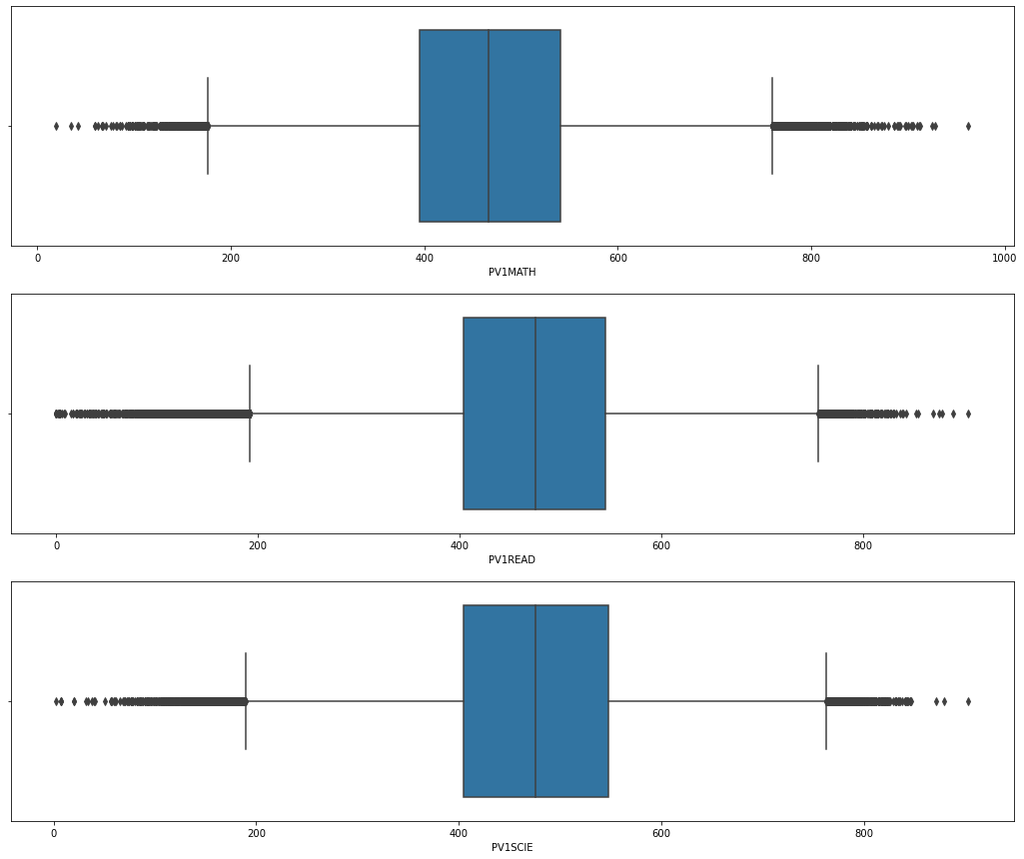

```python
fig, ax = plt.subplots(nrows=3, figsize = [18,15])

default_color = sns.color_palette()[0]
sns.boxplot(data = df, x = 'PV1MATH', color = default_color, ax = ax[0])
sns.boxplot(data = df, x = 'PV1READ', color = default_color, ax = ax[1])
sns.boxplot(data = df, x = 'PV1SCIE', color = default_color, ax = ax[2])

plt.show()
```

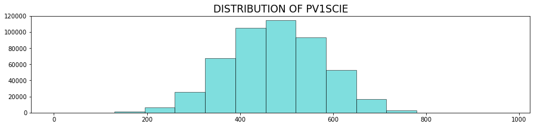

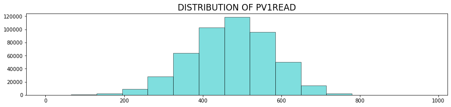

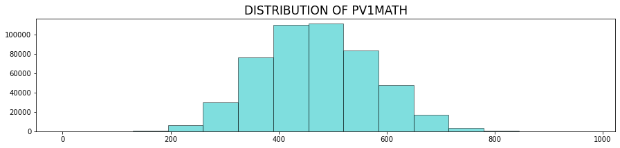

```python
for column in ['PV1SCIE', 'PV1READ', 'PV1MATH']:
    fig, ax1 = plt.subplots(nrows=1, ncols=1, figsize=(15, 3))
    bins = np.arange(0,1000,65)
    ax1.hist(df[column], bins=bins, color='c', alpha=0.5, edgecolor = 'black')
    ax1.set_title(f'DISTRIBUTION OF {column}', fontsize = 17)
    plt.show()
```

The distribution of Maths, science and reading scores is similar. they are all normal distributions. It is interestsing to note however, that though maths has the lowest mean score of the three, it has the largest individual score

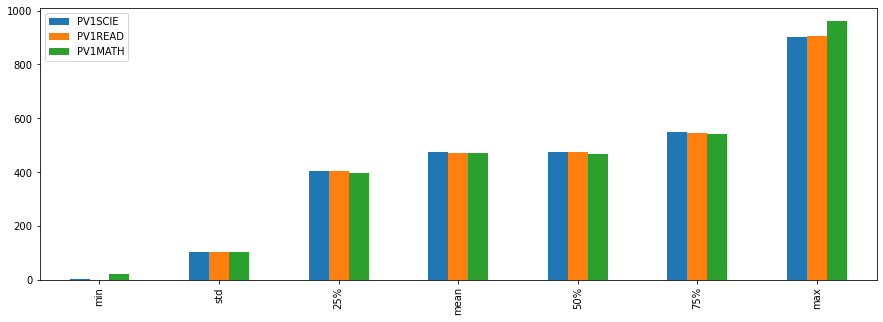

```python
(df[['PV1SCIE', 'PV1READ', 'PV1MATH']]
 .describe()
 .loc[[ 'min', 'std','25%','mean', '50%', '75%', 'max'],:]
 .plot(kind='bar', figsize = (15,5)))
```

```python
df[['PV1SCIE', 'PV1READ', 'PV1MATH']].describe()
```

|  | PV1SCIE | PV1READ | PV1MATH |
| --- | --- | --- | --- |
| count | 485490.000000 | 485490.000000 | 485490.000000 |
| mean | 475.769824 | 472.004640 | 469.621653 |
| std | 101.464426 | 102.505523 | 103.265391 |
| min | 2.648300 | 0.083400 | 19.792800 |
| 25% | 404.457300 | 403.600700 | 395.318600 |
| 50% | 475.699400 | 475.455000 | 466.201900 |
| 75% | 547.780700 | 544.502500 | 541.057800 |
| max | 903.338300 | 904.802600 | 962.229300 |

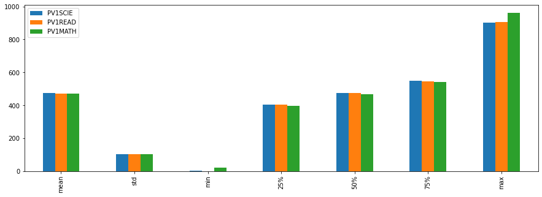

```python
df[['PV1SCIE', 'PV1READ', 'PV1MATH']].describe()[1:].plot(kind='bar', figsize = (15,5))
```

## Problem solving

We shall now look at the distribution of students openness to problem solving

```python
df['OPENPS'].describe()
```

```
count    312766.000000
mean          0.038895
std           0.998720
min          -3.633300
25%          -0.543300
50%           0.052100
75%           0.463900
max           2.446500
Name: OPENPS, dtype: float64
```

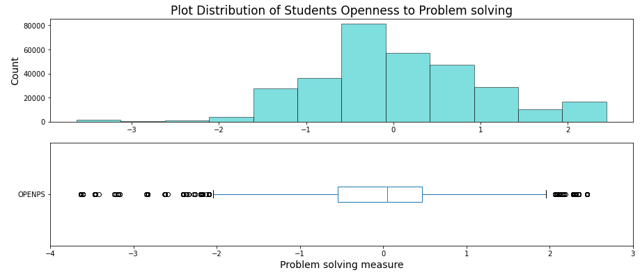

```python
hist_box_dist(column = 'OPENPS', bins = 12,
              title = 'Plot Distribution of Students Openness to Problem solving', xlabel = 'Problem solving measure')
```

## Bivariate Exploration

Let's see which countries have the highest average scores for Math, Reading and Science

## Average Scores Ranking

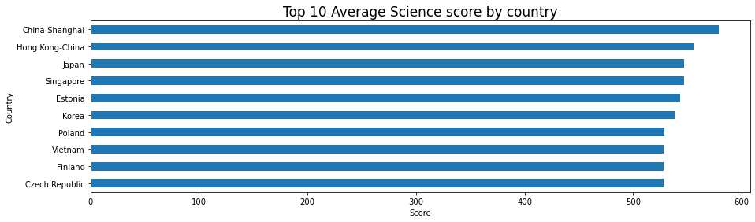

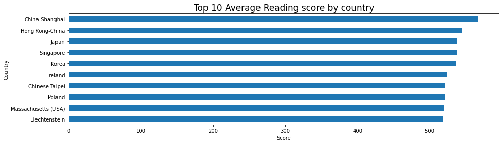

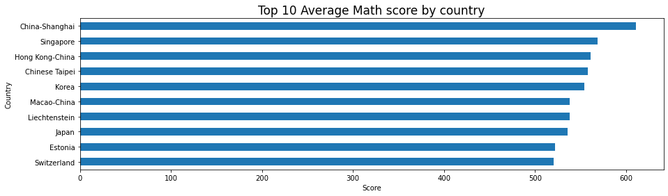

```python
course_dict = {'PV1SCIE' : 'Science',
               'PV1READ' : 'Reading',
               'PV1MATH' : 'Math'}
for column in course_dict:
    (df.groupby('CNT')[column].mean()
     .sort_values(ascending = True)
     .tail(10).plot(kind = "barh", figsize = (15,4)))
    plt.xlabel('Score')
    plt.ylabel('Country')
    plt.title(f'Top 10 Average {course_dict[column]} score by country', fontsize = 17)
    plt.show()
```

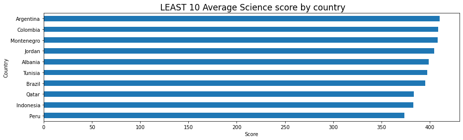

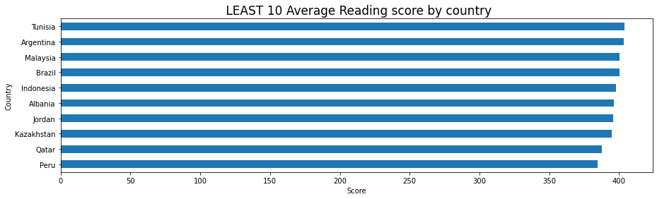

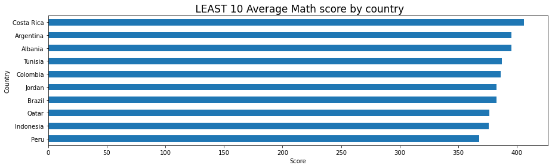

```python
course_dict = {'PV1SCIE' : 'Science',
               'PV1READ' : 'Reading',
               'PV1MATH' : 'Math'}
for column in course_dict:
    (df.groupby('CNT')[column].mean()
     .sort_values(ascending = True)
     .head(10).plot(kind = "barh", figsize = (15,4)))
    plt.xlabel('Score')
    plt.ylabel('Country')
    plt.title(f' LEAST 10 Average {course_dict[column]} score by country', fontsize = 17)
    plt.show()
```

Wow what's happening with the Peruvians?

## Countries out of school study hours

```python
def age_compare_bar(series = None, figsize = (15,6),
                    figures = 2, add_annotate = '',
                    xlabel = None, ylabel = None, title = None):
    plt.subplots(figsize = figsize)
    y = list(range(len(series)))
    plt.barh(y = y, width = series, tick_label = series.index)
    for position in y:
        plt.annotate(str(round(series[position], figures))+ add_annotate, xy=(series[position]+ 1,y[position]))
    plt.xlabel(xlabel, fontsize = 16)
    plt.ylabel(ylabel, fontsize = 16)
    plt.title(title, fontsize = 20)
    plt.show()
```

Let's see the mean average time students spend studying out of school, by country

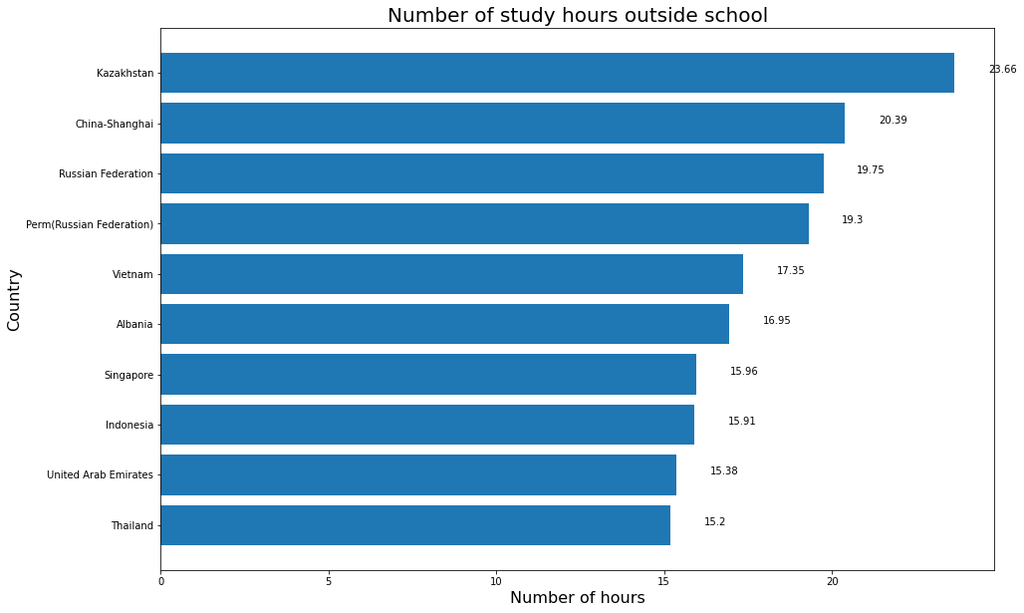

```python
age_compare_bar(series = (df.groupby('CNT')['OUTHOURS']
                          .aggregate(['mean']).sort_values(by = 'mean', ascending = True)
                          .squeeze().tail(10)),
                xlabel = 'Number of hours',
                ylabel = 'Country', figsize = (15,10),
                title = 'Number of study hours outside school', add_annotate = '')
```

```python
df.query("OUTHOURS > 100")["CNT"].value_counts()
```

```
Kazakhstan                  22
United Arab Emirates        16
Brazil                      15
Indonesia                   11
Spain                        9
Italy                        8
Australia                    6
Mexico                       5
Jordan                       5
Thailand                     3
Romania                      3
Montenegro                   3
Russian Federation           3
Luxembourg                   3
Argentina                    3
China-Shanghai               3
Switzerland                  2
Canada                       2
Colombia                     2
United Kingdom               2
Perm(Russian Federation)     2
Uruguay                      2
United States of America     2
Norway                       1
Slovenia                     1
Tunisia                      1
Hong Kong-China              1
France                       1
Vietnam                      1
Singapore                    1
Turkey                       1
Peru                         1
Chile                        1
Portugal                     1
Florida (USA)                1
Lithuania                    1
Iceland                      1
Connecticut (USA)            1
Name: CNT, dtype: int64
```

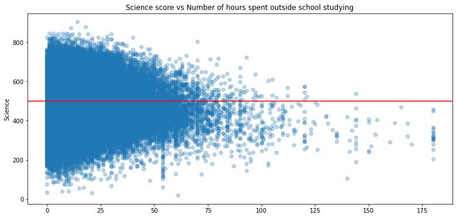

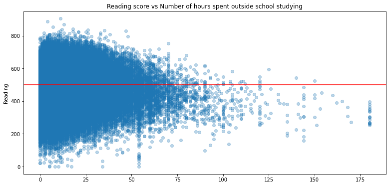

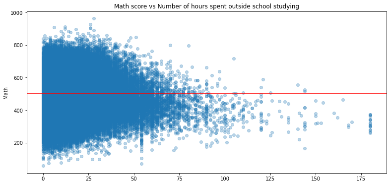

```python
for column in course_dict:
    plt.figure(figsize=[13,6])
    plt.scatter(df['OUTHOURS'], df[column], alpha = 0.3)
    plt.axhline(y=500, color='r')
    plt.ylabel(f"{course_dict[column]}")
    plt.title(f"{course_dict[column]} score vs Number of hours spent outside school studying")
```

Studying outside of school for a longer period doesn't necessarily make you score higher

## Calculators

Let's look at relationshop between calculators and these countries

I'm chosing Peru because it have the lowest scores, Shanghai because it has the highest scores and Indonesia because they have the highest peoportion of students who do not use calculators

```python
def country_calc(country):
    plt.figure(figsize = (13,5))
    (df[df['CNT'] == country]['CLCUSE1'].value_counts(normalize = True) * 100).plot(kind = 'barh')
    plt.xlabel('Percentage of students')
    plt.ylabel('Calculator type')
    plt.title(f'Distribution of calculators in {country}')
```

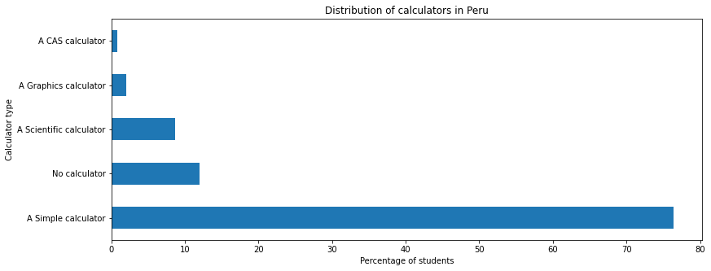

```python
country_calc('Peru')
```

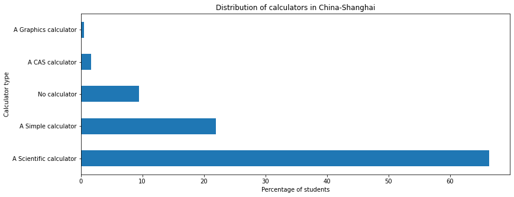

```python
country_calc('China-Shanghai')
```

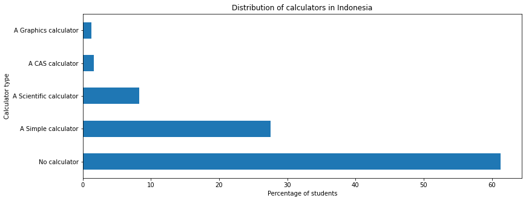

```python
country_calc('Indonesia')
```

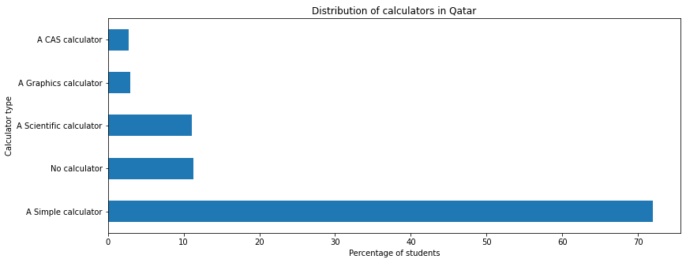

```python
country_calc('Qatar')
```

```python
df.groupby('CNT')['WEALTH'].mean().sort_values(ascending = True).tail(10)
```

```
CNT
Florida (USA)               0.480307
Australia                   0.496489
Canada                      0.508482
Massachusetts (USA)         0.513072
United States of America    0.536442
Liechtenstein               0.541394
United Arab Emirates        0.577770
Norway                      0.693210
Connecticut (USA)           0.693351
Qatar                       0.843554
Name: WEALTH, dtype: float64
```